# Notes on convergence of n-block maxima with Weibull parents distributions to Type 1 asymptotes

Alison Peard

2025-10-19

# Convergence of n-block maxima with Weibull parents distributions to Type 1 asymptotes

Demonstration of convergence of n-block maxima from a Weibull parent distribution to a Fisher–Tippett Type 1 (Gumbel) asymptote. Replicating Fig.~1 of Cook (1982) *Towards better estimation of extreme winds*.

First, choose a shape parameter (`k=2` for Rayleigh, `k=1` for exponential).

```r
k <- 2
```

We want the ordinate to be $y$ to be the same for all plots so define this first. We define the probability from this, so we are sampling the same probabilities from each of the $n$-block maxima distributions. Here, $y$ represents to $-\log(-\log(P(V)))$ or $-\log(-\log(P(V)^n))$, depending which variable we are plotting.

```r
y <- seq(-2, 7, length.out=10000)
p <- exp(-exp(-y))
```

Since we can only sample from the (Weibull) parent distribution, we use Eq.~(6) from Cook (1982),

$$P(x) = P_n(x)^{\frac{1}{n}}$$

where $P(x)$ is the Weibull parent CDF and $P_n(x)$ is the CDF over $n$-block maxima. So we sample from the parent distribution and the distributions of 100- and 10,000-block maxima according to:

```r
v <- qweibull(p, shape=2)
v100 <- qweibull(p^(1/100), shape=2)
v10k <- qweibull(p^(1/10000), shape=2)
```

Cook (1982) used Lieblin’s ``best linear unbiased estimators’’ (BLUE) to get the lines of best fit for each set of samples, but we will just use linear regression for (Eq.~(3)),

$$V = U + \frac{1}{a}y,$$
i.e., intercept $U$ and slope $1/a$, for the samples from the parent and n-block maxima.

```r
fit1 <- lm(v ~ y)
U <- coef(fit1)[[1]]
a <- 1/coef(fit1)[[2]]

fit100 <- lm(v100 ~ y)
U100 <- coef(fit100)[[1]]
a100 <- 1/coef(fit100)[[2]]

fit10k <- lm(v10k ~ y)
U10k <- coef(fit10k)[[1]]
a10k <- 1/coef(fit10k)[[2]]
```

Plot the results.

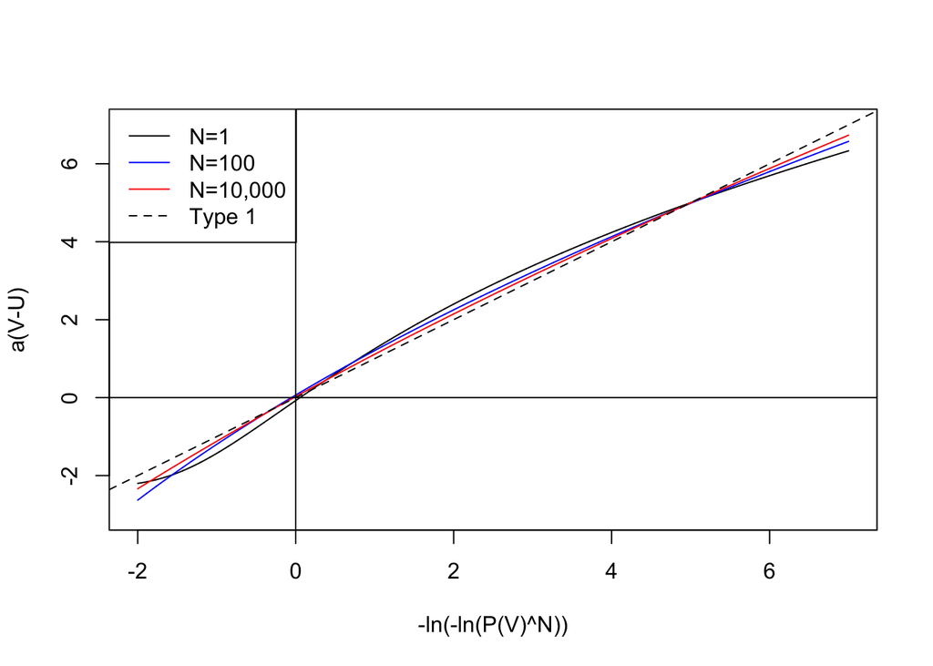

```r
plot(y, a * (v - U), type="l", xlim=c(-2, 7), ylim=c(-3, 7), xlab="-ln(-ln(P(V)^N))", ylab="a(V-U)")
lines(y, a100 * (v100 - U100), col="blue")
lines(y, a10k * (v10k - U10k), col="red")

legend("topleft",
       legend = c("N=1", "N=100", "N=10,000", "Type 1"),
       col = c("black", "blue", "red", "black"),
       lty = c(1, 1, 1, 2),
       lwd = c(1, 1, 1, 1))

abline(h=0);abline(v=0);abline(a=0, b=1, lty=2)
```

#### References

1. Cook, N.J. (1982). Towards better estimation of extreme winds. *Journal of Wind Engineering and Industrial Aerodynamics*, 9, 295–323